# Fatal Police Shootings Dataset

## Data Visualization

### 1. Which State records the most Kill Events by police?

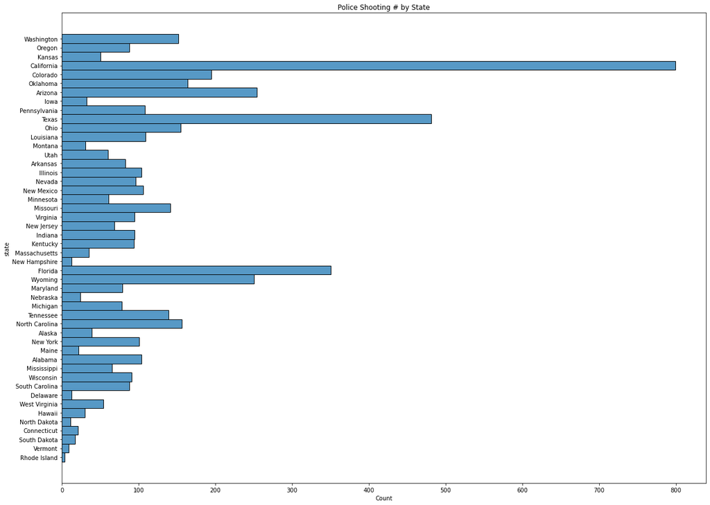

```python
plt.figure(figsize=(20,15))
sns.histplot(y=fatal_police_shootings_data['state'])
plt.title("Police Shooting # by State")
plt.show()
```

From the above plot we can conclude that California has the highest kill events by police.

### Which gender records the most Kill Events by police?

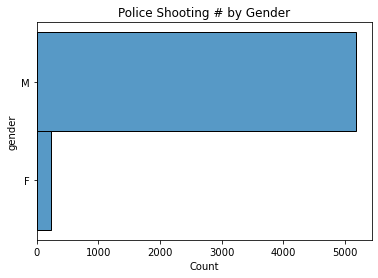

```python
sns.histplot(y=fatal_police_shootings_data['gender'])
plt.title("Police Shooting # by Gender")
plt.show()
```

From the above plot we can conclude that Men's record has the highest kill events by police.

### Which age records the most Kill Events by police?

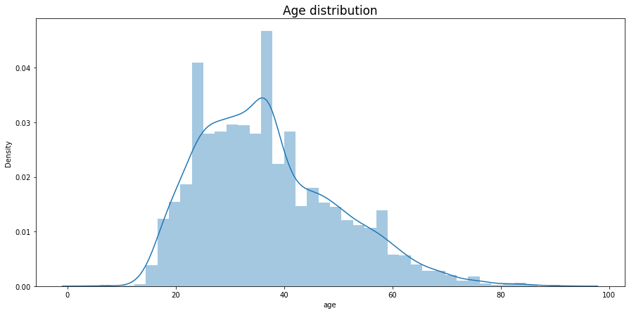

```python
plt.figure(figsize=(15,7))
sns.distplot(fatal_police_shootings_data["age"], bins=40)
plt.title("Age distribution", fontsize=17)
plt.show()
```

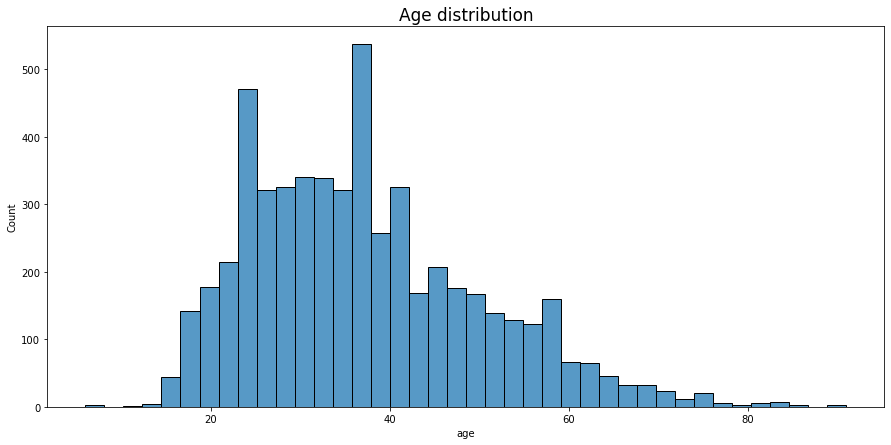

```python
plt.figure(figsize=(15,7))
sns.histplot(fatal_police_shootings_data["age"], bins=40)
plt.title("Age distribution", fontsize=17)
plt.show()
```

```python
bins = [18, 30, 40, 50, 60, 70, 120]
labels = ['18-29', '30-39', '40-49', '50-59', '60-69', '70+']
fatal_police_shootings_data['agerange'] = pd.cut(fatal_police_shootings_data.age, bins, labels = labels,include_lowest = True)
```

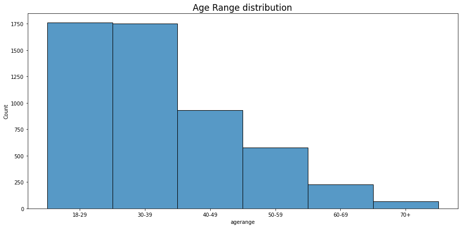

```python
plt.figure(figsize=(15,7))
sns.histplot(fatal_police_shootings_data["agerange"], bins=40)
plt.title("Age Range distribution", fontsize=17)
plt.show()
```

From the above plot we can conclude that age range(18-29) records has the highest kill events by police.

### 4. Which Race records the most Kill Events by police?

[figure not shown]

```python
plt.figure(figsize=(15,7))
sns.histplot(fatal_police_shootings_data["race"], bins=40)
plt.title("Age Range distribution", fontsize=17)
plt.show()
```

From the above plot we can conclude that age white people records has the highest kill events by police.

### 5. Which stage of life records the most Kill Events by police?

[figure not shown]

```python
plt.figure(figsize=(15,7))
sns.histplot(fatal_police_shootings_data["stage"], bins=40)
plt.title("Age Range distribution", fontsize=17)
plt.show()
```

From the above plot we can conclude that age Adult people records has the highest kill events by police.

```python
fatal_police_shootings_data.groupby('year')['id'].count().sort_values(ascending=False).head(5)
```

```
year
2019    1002
2015    994
2018    991
2017    985
2016    962
Name: id, dtype: int64
```

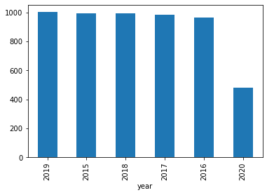

```python
fatal_police_shootings_data.groupby('year')['id'].count().sort_values(ascending=False).plot(kind='bar')
plt.show()
```

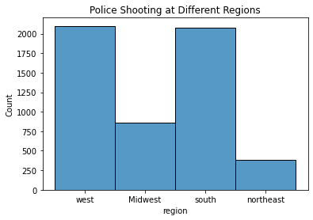

```python
sns.histplot(fatal_police_shootings_data['region'])
plt.title("Police Shooting at Different Regions")
plt.show()
```

From the above Bar plot we can conclude that west and south region has the highest kill events by police.

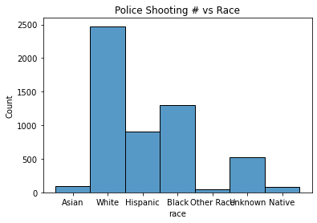

```python
sns.histplot(fatal_police_shootings_data['race'])
plt.title("Police Shooting # vs Race")
plt.show()
```

From the above Bar plot we can conclude that white people record highest kill events by police.

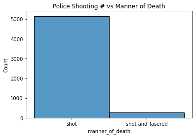

```python
sns.histplot(fatal_police_shootings_data['manner_of_death'])
plt.title("Police Shooting # vs Manner of Death")
plt.show()
```

From the above Bar plot we can conclude that people shot record highest kill events by police.

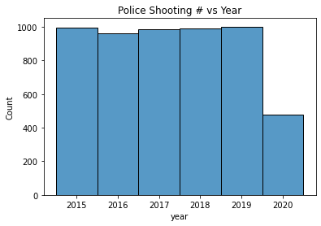

```python
sns.histplot(fatal_police_shootings_data['year'])
plt.title("Police Shooting # vs Year")
plt.show()
```

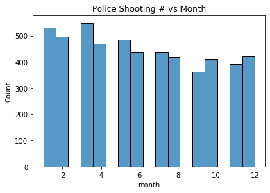

```python
sns.histplot(fatal_police_shootings_data['month'])
plt.title("Police Shooting # vs Month")
plt.show()
```

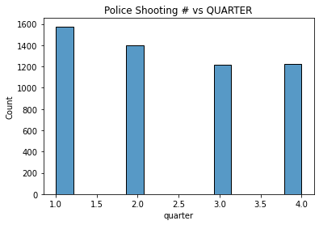

```python
sns.histplot(fatal_police_shootings_data['quarter'])
plt.title("Police Shooting # vs QUARTER")
plt.show()
```

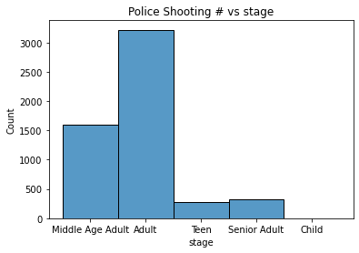

```python
sns.histplot(fatal_police_shootings_data['stage'])
plt.title("Police Shooting # vs stage")
plt.show()
```

```python
fatal_police_shootings_data.shape
```

```
(5414, 21)
```

```python
fatal_police_shootings_data.head()
```

|  | id | name | date | manner_of_death | armed | age | gender | race | city | state | signs_of_mental_illness | threat_level | flee | body_camera | region | year | month | day | quarter | stage | agerange |
| --- | --- | --- | --- | --- | --- | --- | --- | --- | --- | --- | --- | --- | --- | --- | --- | --- | --- | --- | --- | --- | --- |
| 0 | 3 | Tim Elliot | 2015-01-02 | shot | gun | 53 | M | Asian | Shelton | Washington | True | attack | Not fleeing | False | west | 2015 | 1 | 02 | 1 | Middle Age Adult | 50-59 |
| 1 | 4 | Lewis Lee Lembke | 2015-01-02 | shot | gun | 47 | M | White | Aloha | Oregon | False | attack | Not fleeing | False | west | 2015 | 1 | 02 | 1 | Middle Age Adult | 40-49 |
| 2 | 5 | John Paul Quintero | 2015-01-03 | shot and Tasered | unarmed | 23 | M | Hispanic | Wichita | Kansas | False | other | Not fleeing | False | Midwest | 2015 | 1 | 03 | 1 | Adult | 18-29 |
| 3 | 8 | Matthew Hoffman | 2015-01-04 | shot | toy weapon | 32 | M | White | San Francisco | California | True | attack | Not fleeing | False | west | 2015 | 1 | 04 | 1 | Adult | 30-39 |
| 4 | 9 | Michael Rodriguez | 2015-01-04 | shot | nail gun | 39 | M | Hispanic | Evans | Colorado | False | attack | Not fleeing | False | west | 2015 | 1 | 04 | 1 | Adult | 30-39 |

### Model

```python
from sklearn import model_selection
from sklearn.model_selection import train_test_split
from sklearn.metrics import classification_report, confusion_matrix
from sklearn.ensemble import RandomForestClassifier
from sklearn.metrics import accuracy_score
```

#### Dropping columns and creating dummy varaibles.

```python
fatal_police_shootings_data["signs_of_mental_illness"] = fatal_police_shootings_data["signs_of_mental_illness"].astype(int)
fatal_police_shootings_data["body_camera"] = fatal_police_shootings_data["body_camera"].astype(int)
fatal_police_shootings_data["year"] = fatal_police_shootings_data["year"].astype(int)
fatal_police_shootings_data["day"] = fatal_police_shootings_data["day"].astype(int)
```

```python
fatal_police_shootings_data.iloc[1,]
```

```
id                         4
name                       Lewis Lee Lembke
date                       2015-01-02
manner_of_death            shot
armed                      gun
age                        47
gender                     M
race                       White
city                       Aloha
state                      Oregon
signs_of_mental_illness    0
threat_level               attack
flee                       Not fleeing
body_camera                0
region                     west
year                       2015
month                      1
day                        2
quarter                    1
stage                      Middle Age Adult
agerange                   40-49
Name: 1, dtype: object
```

```python
# Creating a dummy variable for some of the categorical variables and dropping the first one.
dummy1 = pd.get_dummies(fatal_police_shootings_data[['race','stage','manner_of_death','gender','threat_level','body_camera','region','flee','body_camera']], drop_first=True)

# Adding the results to the master dataframe
fatal_police_shootings_data = pd.concat([fatal_police_shootings_data, dummy1], axis=1)
```

```python
#Dropping all the columns
fatal_police_shootings_data.drop(['id','name','date','age','city','state','agerange','race','armed','stage','manner_of_death','armed','gender','threat_level','body_camera','region','flee','body_camera','race_Black','race_Hispanic','race_Native','race_Other Race','race_Unknown'], inplace=True, axis = 1)
```

```python
fatal_police_shootings_data.head()
```

|  | signs_of_mental_illness | year | month | day | quarter | race_White | stage_Child | stage_Middle Age Adult | stage_Senior Adult | stage_Teen | manner_of_death_shot and Tasered | gender_M | threat_level_other | threat_level_undetermined | region_northeast | region_south | region_west | flee_Foot | flee_Not fleeing | flee_Other | flee_Unknow |
| --- | --- | --- | --- | --- | --- | --- | --- | --- | --- | --- | --- | --- | --- | --- | --- | --- | --- | --- | --- | --- | --- |
| 0 | 1 | 2015 | 1 | 2 | 1 | 0 | 0 | 1 | 0 | 0 | 0 | 1 | 0 | 0 | 0 | 0 | 1 | 0 | 1 | 0 | 0 |
| 1 | 0 | 2015 | 1 | 2 | 1 | 1 | 0 | 1 | 0 | 0 | 0 | 1 | 0 | 0 | 0 | 0 | 1 | 0 | 1 | 0 | 0 |
| 2 | 0 | 2015 | 1 | 3 | 1 | 0 | 0 | 0 | 0 | 0 | 1 | 1 | 1 | 0 | 0 | 0 | 0 | 0 | 1 | 0 | 0 |
| 3 | 1 | 2015 | 1 | 4 | 1 | 1 | 0 | 0 | 0 | 0 | 0 | 1 | 0 | 0 | 0 | 0 | 1 | 0 | 1 | 0 | 0 |
| 4 | 0 | 2015 | 1 | 4 | 1 | 0 | 0 | 0 | 0 | 0 | 0 | 1 | 0 | 0 | 0 | 0 | 1 | 0 | 1 | 0 | 0 |

```python
fatal_police_shootings_data.dtypes #Data types
```

```
signs_of_mental_illness             int64
year                                int64
month                               int64
day                                 int64
quarter                             int64
race_White                          uint8
stage_Child                         uint8
stage_Middle Age Adult              uint8
stage_Senior Adult                  uint8
stage_Teen                          uint8
manner_of_death_shot and Tasered    uint8
gender_M                            uint8
threat_level_other                  uint8
threat_level_undetermined           uint8
region_northeast                    uint8
region_south                        uint8
region_west                         uint8
flee_Foot                           uint8
flee_Not fleeing                    uint8
flee_Other                          uint8
flee_Unknow                         uint8
dtype: object
```

```python
fatal_police_shootings_data.corr() #Correlation
```

|  | signs_of_mental_illness | year | month | day | quarter | race_White | stage_Child | stage_Middle Age Adult | stage_Senior Adult | stage_Teen | manner_of_death_shot and Tasered | gender_M | threat_level_other | threat_level_undetermined | region_northeast | region_south | region_west | flee_Foot | flee_Not fleeing | flee_Other | flee_Unknow |
| --- | --- | --- | --- | --- | --- | --- | --- | --- | --- | --- | --- | --- | --- | --- | --- | --- | --- | --- | --- | --- | --- |
| signs_of_mental_illness | 1.000000 | -0.079793 | -0.027414 | -0.012883 | -0.027979 | 0.139144 | -0.012666 | 0.046150 | 0.069599 | -0.049465 | 0.051675 | -0.040144 | 0.049520 | -0.038010 | 0.035478 | -0.018618 | -0.009339 | -0.103822 | 0.216149 | -0.051159 | -0.050473 |
| year | -0.079793 | 1.000000 | -0.144381 | -0.034222 | -0.144875 | -0.068819 | -0.018760 | -0.006574 | 0.024894 | -0.019048 | -0.055736 | 0.001848 | 0.014456 | -0.022800 | -0.008355 | 0.025210 | -0.007349 | 0.028428 | -0.098856 | -0.013465 | 0.128845 |
| month | -0.027414 | -0.144381 | 1.000000 | 0.012068 | 0.971874 | -0.022908 | 0.012583 | -0.009863 | 0.017113 | 0.004009 | -0.026118 | -0.000444 | -0.060597 | 0.063321 | 0.007092 | -0.019343 | 0.026681 | -0.030535 | 0.028057 | -0.006401 | 0.020344 |
| day | -0.012883 | -0.034222 | 0.012068 | 1.000000 | 0.014092 | -0.004378 | -0.010333 | 0.003417 | -0.038777 | 0.012755 | 0.010155 | -0.036780 | -0.017706 | 0.002217 | -0.003146 | 0.000605 | 0.009919 | 0.000146 | -0.022039 | 0.010573 | -0.007774 |
| quarter | -0.027979 | -0.144875 | 0.971874 | 0.014092 | 1.000000 | -0.021340 | 0.012817 | -0.011233 | 0.015100 | 0.007604 | -0.018271 | -0.000063 | -0.057437 | 0.055577 | 0.003746 | -0.026290 | 0.030571 | -0.026623 | 0.028493 | -0.007016 | 0.010034 |
| race_White | 0.139144 | -0.068819 | -0.022908 | -0.004378 | -0.021340 | 1.000000 | 0.025659 | 0.169859 | 0.081102 | -0.083321 | -0.012656 | -0.049192 | -0.021208 | -0.029346 | -0.007500 | 0.056344 | -0.108821 | -0.094776 | 0.074582 | -0.002103 | -0.031561 |
| stage_Child | -0.012666 | -0.018760 | 0.012583 | -0.010333 | 0.012817 | 0.025659 | 1.000000 | -0.015203 | -0.005941 | -0.005436 | -0.005395 | -0.033236 | 0.035089 | -0.005060 | 0.024208 | 0.013736 | -0.018744 | -0.009014 | 0.001795 | -0.004162 | -0.005170 |
| stage_Middle Age Adult | 0.046150 | -0.006574 | -0.009863 | 0.003417 | -0.011233 | 0.169859 | -0.015203 | 1.000000 | -0.162904 | -0.149078 | 0.008483 | -0.011807 | -0.004917 | -0.022342 | 0.010927 | 0.023139 | -0.019047 | -0.089362 | 0.110515 | -0.038442 | -0.004383 |
| stage_Senior Adult | 0.069599 | 0.024894 | 0.017113 | -0.038777 | 0.015100 | 0.081102 | -0.005941 | -0.162904 | 1.000000 | -0.058252 | -0.014875 | 0.016117 | -0.038034 | -0.023893 | 0.018873 | 0.047865 | -0.045824 | -0.082590 | 0.109551 | -0.040048 | 0.030107 |
| stage_Teen | -0.049465 | -0.019048 | 0.004009 | 0.012755 | 0.007604 | -0.083321 | -0.005436 | -0.149078 | -0.058252 | 1.000000 | -0.002573 | 0.020737 | 0.003506 | 0.032424 | 0.008954 | -0.015538 | -0.009131 | 0.073134 | -0.081287 | 0.032941 | -0.006444 |
| manner_of_death_shot and Tasered | 0.051675 | -0.055736 | -0.026118 | 0.010155 | -0.018271 | -0.012656 | -0.005395 | 0.008483 | -0.014875 | -0.002573 | 1.000000 | 0.024293 | 0.079164 | -0.020320 | 0.023220 | -0.018208 | 0.023111 | -0.003839 | 0.047345 | 0.009017 | -0.005743 |
| gender_M | -0.040144 | 0.001848 | -0.000444 | -0.036780 | -0.000063 | -0.049192 | -0.033236 | -0.011807 | 0.016117 | 0.020737 | 0.024293 | 1.000000 | -0.029409 | 0.015380 | 0.023773 | -0.007092 | -0.016057 | 0.055104 | -0.030035 | 0.022129 | 0.008371 |
| threat_level_other | 0.049520 | 0.014456 | -0.060597 | -0.017706 | -0.057437 | -0.021208 | 0.035089 | -0.004917 | -0.038034 | 0.003506 | 0.079164 | -0.029409 | 1.000000 | -0.144211 | -0.003585 | -0.046772 | 0.056503 | -0.014180 | 0.010934 | -0.009132 | 0.008934 |
| threat_level_undetermined | -0.038010 | -0.022800 | 0.063321 | 0.002217 | 0.055577 | -0.029346 | -0.005060 | -0.022342 | -0.023893 | 0.032424 | -0.020320 | 0.015380 | -0.144211 | 1.000000 | -0.002880 | -0.006578 | 0.020845 | 0.022761 | -0.068035 | 0.014481 | 0.128815 |
| region_northeast | 0.035478 | -0.008355 | 0.007092 | -0.003146 | 0.003746 | -0.007500 | 0.024208 | 0.010927 | 0.018873 | 0.008954 | 0.023220 | 0.023773 | -0.003585 | -0.002880 | 1.000000 | -0.216810 | -0.219019 | 0.020118 | 0.006024 | -0.010707 | 0.005092 |
| region_south | -0.018618 | 0.025210 | -0.019343 | 0.000605 | -0.026290 | 0.056344 | 0.013736 | 0.023139 | 0.047865 | -0.015538 | -0.018208 | -0.007092 | -0.046772 | -0.006578 | -0.216810 | 1.000000 | -0.627284 | -0.036519 | 0.009989 | 0.020339 | -0.007958 |
| region_west | -0.009339 | -0.007349 | 0.026681 | 0.009919 | 0.030571 | -0.108821 | -0.018744 | -0.019047 | -0.045824 | -0.009131 | 0.023111 | -0.016057 | 0.056503 | 0.020845 | -0.219019 | -0.627284 | 1.000000 | 0.016558 | -0.012311 | -0.016838 | 0.013422 |
| flee_Foot | -0.103822 | 0.028428 | -0.030535 | 0.000146 | -0.026623 | -0.094776 | -0.009014 | -0.089362 | -0.082590 | 0.073134 | -0.003839 | 0.055104 | -0.014180 | 0.022761 | 0.020118 | -0.036519 | 0.016558 | 1.000000 | -0.499365 | -0.067660 | -0.084053 |
| flee_Not fleeing | 0.216149 | -0.098856 | 0.028057 | -0.022039 | 0.028493 | 0.074582 | 0.001795 | 0.110515 | 0.109551 | -0.081287 | 0.047345 | -0.030035 | 0.010934 | -0.068035 | 0.006024 | 0.009989 | -0.012311 | -0.499365 | 1.000000 | -0.230553 | -0.286413 |
| flee_Other | -0.051159 | -0.013465 | -0.006401 | 0.010573 | -0.007016 | -0.002103 | -0.004162 | -0.038442 | -0.040048 | 0.032941 | 0.009017 | 0.022129 | -0.009132 | 0.014481 | -0.010707 | 0.020339 | -0.016838 | -0.067660 | -0.230553 | 1.000000 | -0.038807 |
| flee_Unknow | -0.050473 | 0.128845 | 0.020344 | -0.007774 | 0.010034 | -0.031561 | -0.005170 | -0.004383 | 0.030107 | -0.006444 | -0.005743 | 0.008371 | 0.008934 | 0.128815 | 0.005092 | -0.007958 | 0.013422 | -0.084053 | -0.286413 | -0.038807 | 1.000000 |

```python
fatal_police_shootings_data.head()
```

|  | signs_of_mental_illness | year | month | day | quarter | race_White | stage_Child | stage_Middle Age Adult | stage_Senior Adult | stage_Teen | manner_of_death_shot and Tasered | gender_M | threat_level_other | threat_level_undetermined | region_northeast | region_south | region_west | flee_Foot | flee_Not fleeing | flee_Other | flee_Unknow |
| --- | --- | --- | --- | --- | --- | --- | --- | --- | --- | --- | --- | --- | --- | --- | --- | --- | --- | --- | --- | --- | --- |
| 0 | 1 | 2015 | 1 | 2 | 1 | 0 | 0 | 1 | 0 | 0 | 0 | 1 | 0 | 0 | 0 | 0 | 1 | 0 | 1 | 0 | 0 |
| 1 | 0 | 2015 | 1 | 2 | 1 | 1 | 0 | 1 | 0 | 0 | 0 | 1 | 0 | 0 | 0 | 0 | 1 | 0 | 1 | 0 | 0 |
| 2 | 0 | 2015 | 1 | 3 | 1 | 0 | 0 | 0 | 0 | 0 | 1 | 1 | 1 | 0 | 0 | 0 | 0 | 0 | 1 | 0 | 0 |
| 3 | 1 | 2015 | 1 | 4 | 1 | 1 | 0 | 0 | 0 | 0 | 0 | 1 | 0 | 0 | 0 | 0 | 1 | 0 | 1 | 0 | 0 |
| 4 | 0 | 2015 | 1 | 4 | 1 | 0 | 0 | 0 | 0 | 0 | 0 | 1 | 0 | 0 | 0 | 0 | 1 | 0 | 1 | 0 | 0 |

```python
# Putting feature variable to X
X = fatal_police_shootings_data.drop(['race_White'], axis=1)
y = fatal_police_shootings_data['race_White']
```

```python
# Splitting the data into train and test
X_train, X_test, y_train, y_test = train_test_split(X, y, train_size=0.7, test_size=0.3, random_state=100)
```